# BMI, obesity-related genetic polymorphisms and reward network structural connectivity

Frauke Beyer. Markus Scholz, Rui Zhang, Kerstin Wirkner, Markus Loeffler, Michael Stumvoll, Arno Villringer, A. Veronica Witte

July 22, 2020

Here, you find the main analysis steps for the publication " Higher BMI, but not obesity-related genetic polymorphisms, correlates with lower structural connectivity of the reward network in a population-based study" with a synthetic dataset based on the real data.

# 1 Descriptives of the dataset

(#tab:create descriptives of sample)Demographics of synthetic dataset

|  | vars | n | mean | sd | median | trimmed | mad | min | max | range | skew | kurtosis | se |
| --- | --- | --- | --- | --- | --- | --- | --- | --- | --- | --- | --- | --- | --- |
| Age_all | 1 | 347 | 45.5878963 | 8.7828770 | 47.0000000 | 46.3154122 | 7.4130000 | 20.0000000 | 59.0000000 | 39.0000000 | -0.7359786 | 0.3277842 | 0.4714895 |
| BMI_BMI | 2 | 347 | 25.3998596 | 3.6585838 | 25.2314815 | 25.2832611 | 3.2841390 | 17.6783410 | 38.3241988 | 20.6458578 | 0.3844325 | 0.5127862 | 0.1964031 |
| rel_FA_CC | 3 | 347 | 1.4611221 | 0.2097399 | 1.4489306 | 1.4565192 | 0.2365704 | 0.9155065 | 2.0567987 | 1.1412922 | 0.1886069 | -0.1732922 | 0.0112594 |
| rel_FA_strength | 4 | 347 | 0.0435845 | 0.0076132 | 0.0436269 | 0.0434905 | 0.0077428 | 0.0263114 | 0.0686651 | 0.0423537 | 0.2912218 | 0.5455424 | 0.0004087 |
| rel_NOS_CC | 5 | 347 | 8.1262148 | 3.5476412 | 7.6378453 | 7.7284895 | 2.6444879 | 2.2823452 | 26.0352133 | 23.7528681 | 1.7706232 | 5.6461770 | 0.1904474 |
| rel_NOS_strength | 6 | 347 | 0.0568088 | 0.0166806 | 0.0538140 | 0.0561768 | 0.0158062 | 0.0234378 | 0.1117190 | 0.0882812 | 0.5878123 | 0.7175537 | 0.0008955 |

```
##
## female   male
##    178    169
```

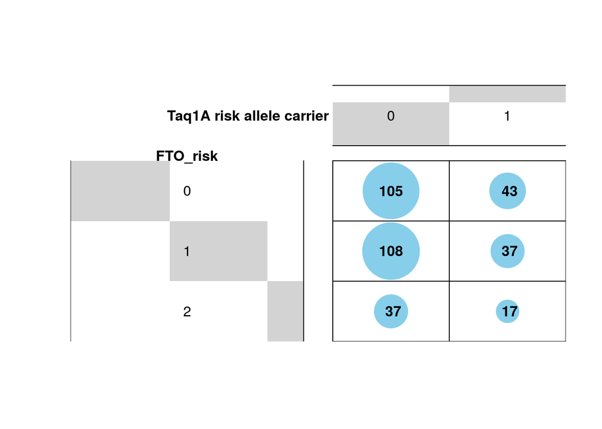

Check for Hardy-Weinberg equilibrium of FTO risk allele.

```
## Chi-square test with continuity correction for Hardy-Weinberg equilibrium (autosomal)
## Chi2 =  3.021436 DF =  1 p-value =  0.0821707 D =  -7.884006 f =  0.09807928
```

# 2 Association of BMI and reward network connectivity

Here, we test for the linear association of BMI and reward network connectivity measures. If BMI is significant based on `anova` model comparison, we would perform the second analysis adjusting for covariates (not included in the synthetic dataset).

## 2.1 FA CC ~ BMI

```
## Analysis of Variance Table
##
## Model 1: rel_FA_CC ~ Age_all + factor(sex) + BMI_BMI
## Model 2: rel_FA_CC ~ Age_all + factor(sex)
##   Res.Df    RSS Df Sum of Sq      F   Pr(>F)
## 1    343 13.104
## 2    344 13.419 -1  -0.31489 8.2423 0.004347 **
## ---
## Signif. codes:  0 '***' 0.001 '**' 0.01 '*' 0.05 '.' 0.1 ' ' 1
```

```
##
## Call:
## lm(formula = rel_FA_CC ~ Age_all + factor(sex) + BMI_BMI, data = final_sample)
##
## Residuals:
##      Min       1Q   Median       3Q      Max
## -0.48922 -0.12509 -0.00963  0.12895  0.60787
##
## Coefficients:
##                  Estimate Std. Error t value Pr(>|t|)
## (Intercept)      1.981510   0.080298  24.677  < 2e-16 ***
## Age_all         -0.005769   0.001278  -4.514 8.77e-06 ***
## factor(sex)male -0.053973   0.021740  -2.483  0.01352 *
## BMI_BMI         -0.009100   0.003170  -2.871  0.00435 **
## ---
## Signif. codes:  0 '***' 0.001 '**' 0.01 '*' 0.05 '.' 0.1 ' ' 1
##
## Residual standard error: 0.1955 on 343 degrees of freedom
## Multiple R-squared:  0.1391, Adjusted R-squared:  0.1315
## F-statistic: 18.47 on 3 and 343 DF,  p-value: 3.956e-11
```

```
##                       2.5 %       97.5 %
## (Intercept)      1.82357136  2.139447714
## Age_all         -0.00828220 -0.003254806
## factor(sex)male -0.09673253 -0.011212861
## BMI_BMI         -0.01533369 -0.002865391
```

```
##                                    2.5 %       97.5 %
## (Intercept)      1.981509537  1.82357136  2.139447714
## Age_all         -0.005768503 -0.00828220 -0.003254806
## factor(sex)male -0.053972695 -0.09673253 -0.011212861
## BMI_BMI         -0.009099541 -0.01533369 -0.002865391
```

```
##                   2.5 %  97.5 %
## (Intercept)      1.8236  2.1394
## Age_all         -0.0083 -0.0033
## factor(sex)male -0.0967 -0.0112
## BMI_BMI         -0.0153 -0.0029
```

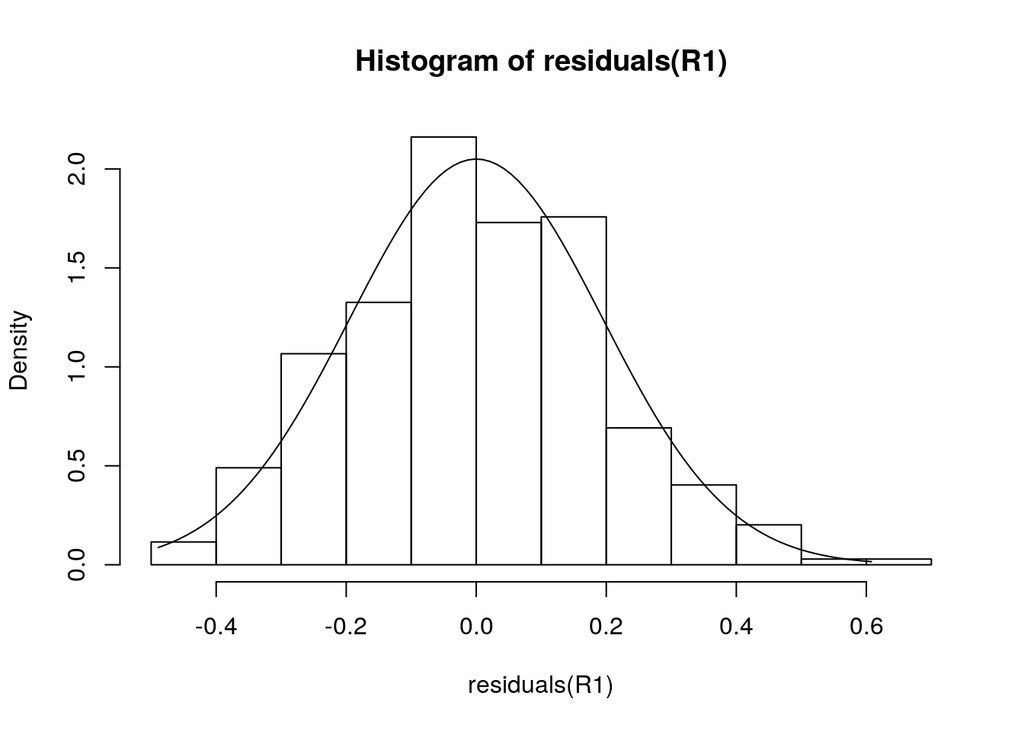

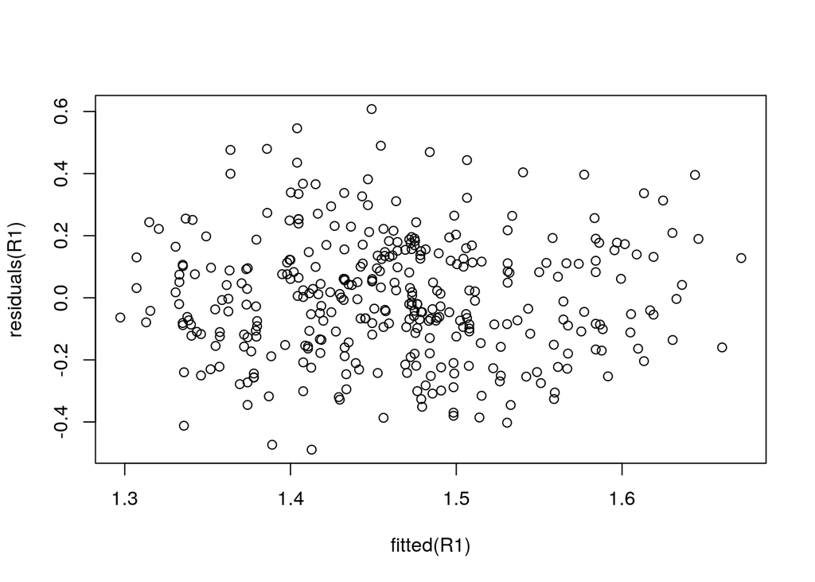

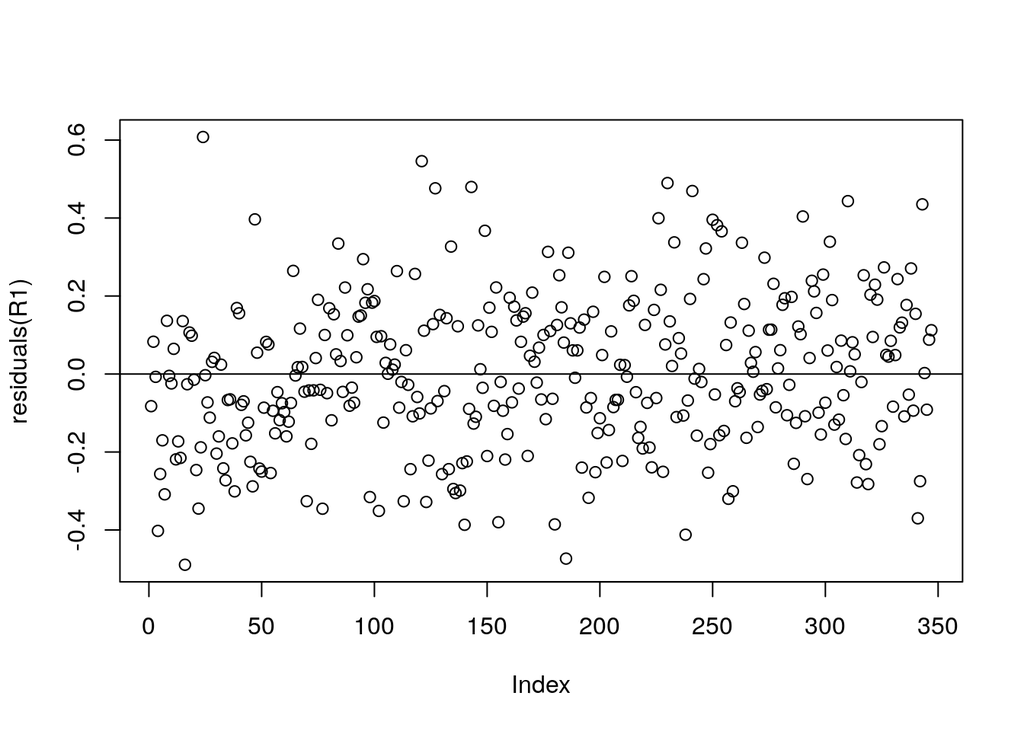

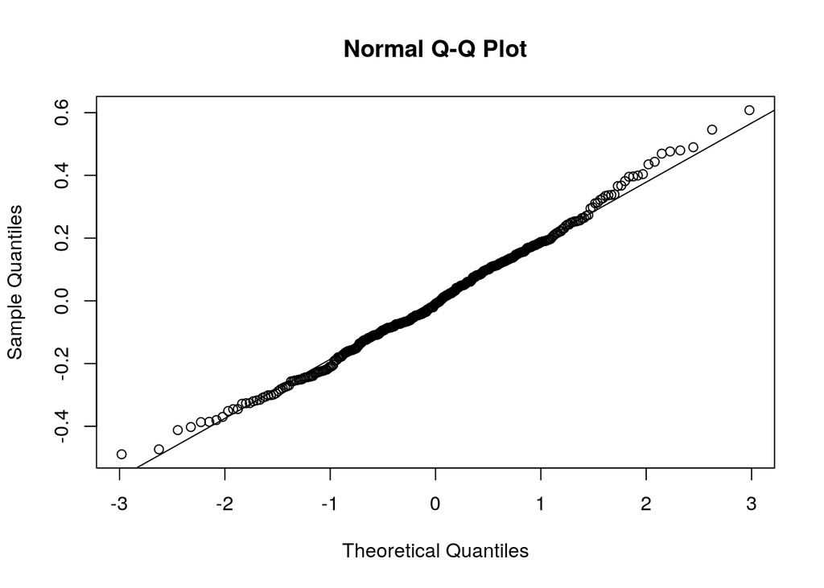

```
## [1] 0.4461792
```

```
##     (Intercept)       Age_all factor(sex)male       BMI_BMI
## 1 -0.0007693991  1.455519e-05   -5.079195e-04  4.483243e-06
## 2  0.0012826495  6.683616e-05    7.925594e-04 -1.759767e-04
## 3  0.0003398553 -1.068708e-06    6.768045e-05 -1.360645e-05
## 4 -0.0092729676  2.783428e-04   -2.326254e-03 -1.363317e-04
## 5  0.0034796945 -4.003745e-05   -1.380127e-03 -6.797802e-05
## 6 -0.0055798618  5.403114e-05    7.721862e-04  8.839087e-05
```

```
##                     orig      min      max
## (Intercept)      1.98151  1.96916  2.00125
## Age_all         -0.00577 -0.00602 -0.00546
## factor(sex)male -0.05397 -0.05770 -0.04891
## BMI_BMI         -0.00910 -0.01036 -0.00832
```

```
## [1] 0.05141882
```

```
##     Age_all factor(sex)     BMI_BMI
##    1.141023    1.072428    1.217798
```

```
##     Age_all factor(sex)     BMI_BMI
##   0.8764065   0.9324636   0.8211540
```

```
## [1] 1.14375
```

## 2.2 FA CS ~ BMI (Model 1)

```
## Analysis of Variance Table
##
## Model 1: rel_FA_strength ~ Age_all + factor(sex) + BMI_BMI
## Model 2: rel_FA_strength ~ Age_all + factor(sex)
##   Res.Df      RSS Df   Sum of Sq      F  Pr(>F)
## 1    343 0.016789
## 2    344 0.017109 -1 -0.00031983 6.5339 0.01101 *
## ---
## Signif. codes:  0 '***' 0.001 '**' 0.01 '*' 0.05 '.' 0.1 ' ' 1
```

```
##
## Call:
## lm(formula = rel_FA_strength ~ Age_all + factor(sex) + BMI_BMI,
##     data = final_sample)
##
## Residuals:
##        Min         1Q     Median         3Q        Max
## -0.0171596 -0.0042095  0.0003882  0.0040681  0.0266123
##
## Coefficients:
##                   Estimate Std. Error t value Pr(>|t|)
## (Intercept)      6.231e-02  2.874e-03  21.678  < 2e-16 ***
## Age_all         -2.169e-04  4.574e-05  -4.741 3.12e-06 ***
## factor(sex)male -3.020e-03  7.782e-04  -3.881 0.000125 ***
## BMI_BMI         -2.900e-04  1.135e-04  -2.556 0.011014 *
## ---
## Signif. codes:  0 '***' 0.001 '**' 0.01 '*' 0.05 '.' 0.1 ' ' 1
##
## Residual standard error: 0.006996 on 343 degrees of freedom
## Multiple R-squared:  0.1628, Adjusted R-squared:  0.1555
## F-statistic: 22.24 on 3 and 343 DF,  p-value: 3.521e-13
```

```
##                         2.5 %        97.5 %
## (Intercept)      0.0566547687  6.796134e-02
## Age_all         -0.0003068461 -1.268941e-04
## factor(sex)male -0.0045509286 -1.489812e-03
## BMI_BMI         -0.0005131443 -6.685033e-05
```

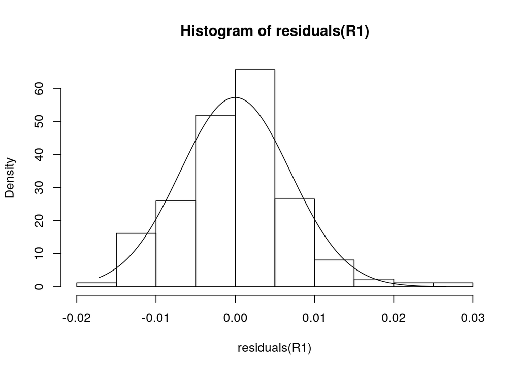

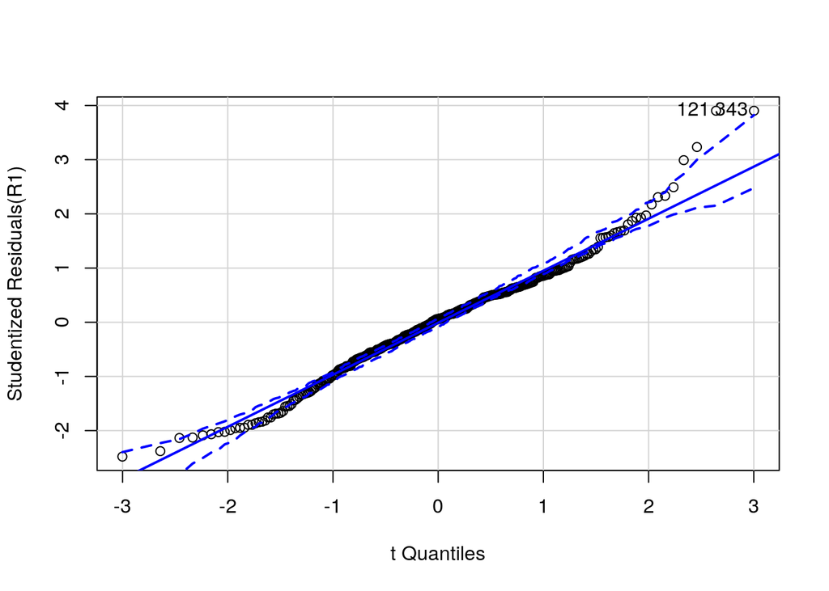

```
## [1] 121 343
```

## 2.3 NOS CC ~ BMI (Model 1)

```
## Analysis of Variance Table
##
## Model 1: rel_NOS_CC ~ Age_all + factor(sex) + BMI_BMI
## Model 2: rel_NOS_CC ~ Age_all + factor(sex)
##   Res.Df    RSS Df Sum of Sq      F Pr(>F)
## 1    343 4297.2
## 2    344 4328.3 -1   -31.102 2.4825  0.116
```

```
##
## Call:
## lm(formula = rel_NOS_CC ~ Age_all + factor(sex) + BMI_BMI, data = final_sample)
##
## Residuals:
##     Min      1Q  Median      3Q     Max
## -5.8962 -2.3063 -0.6183  1.2317 17.4401
##
## Coefficients:
##                 Estimate Std. Error t value Pr(>|t|)
## (Intercept)      9.18102    1.45410   6.314 8.42e-10 ***
## Age_all          0.03051    0.02314   1.318    0.188
## factor(sex)male -0.30496    0.39368  -0.775    0.439
## BMI_BMI         -0.09043    0.05740  -1.576    0.116
## ---
## Signif. codes:  0 '***' 0.001 '**' 0.01 '*' 0.05 '.' 0.1 ' ' 1
##
## Residual standard error: 3.54 on 343 degrees of freedom
## Multiple R-squared:  0.01319,    Adjusted R-squared:  0.004559
## F-statistic: 1.528 on 3 and 343 DF,  p-value: 0.2069
```

```
##                       2.5 %      97.5 %
## (Intercept)      6.32094779 12.04109517
## Age_all         -0.01501405  0.07602611
## factor(sex)male -1.07928571  0.46937438
## BMI_BMI         -0.20332623  0.02245991
```

## 2.4 NOS CS ~ BMI (Model 1)

```
## Analysis of Variance Table
##
## Model 1: rel_NOS_strength ~ Age_all + factor(sex)
## Model 2: rel_NOS_strength ~ Age_all + factor(sex) + BMI_BMI
##   Res.Df      RSS Df Sum of Sq     F   Pr(>F)
## 1    344 0.086589
## 2    343 0.083354  1 0.0032346 13.31 0.000305 ***
## ---
## Signif. codes:  0 '***' 0.001 '**' 0.01 '*' 0.05 '.' 0.1 ' ' 1
```

```
##
## Call:
## lm(formula = rel_NOS_strength ~ Age_all + factor(sex) + BMI_BMI,
##     data = final_sample)
##
## Residuals:
##       Min        1Q    Median        3Q       Max
## -0.037285 -0.010159 -0.000842  0.009660  0.054109
##
## Coefficients:
##                   Estimate Std. Error t value Pr(>|t|)
## (Intercept)      0.0924347  0.0064042  14.433  < 2e-16 ***
## Age_all         -0.0001915  0.0001019  -1.879 0.061069 .
## factor(sex)male -0.0071231  0.0017339  -4.108 4.99e-05 ***
## BMI_BMI         -0.0009222  0.0002528  -3.648 0.000305 ***
## ---
## Signif. codes:  0 '***' 0.001 '**' 0.01 '*' 0.05 '.' 0.1 ' ' 1
##
## Residual standard error: 0.01559 on 343 degrees of freedom
## Multiple R-squared:  0.1342, Adjusted R-squared:  0.1266
## F-statistic: 17.72 on 3 and 343 DF,  p-value: 1.026e-10
```

```
##                         2.5 %        97.5 %
## (Intercept)      0.0798382665  1.050311e-01
## Age_all         -0.0003920186  8.942518e-06
## factor(sex)male -0.0105334574 -3.712813e-03
## BMI_BMI         -0.0014194511 -4.250386e-04
```

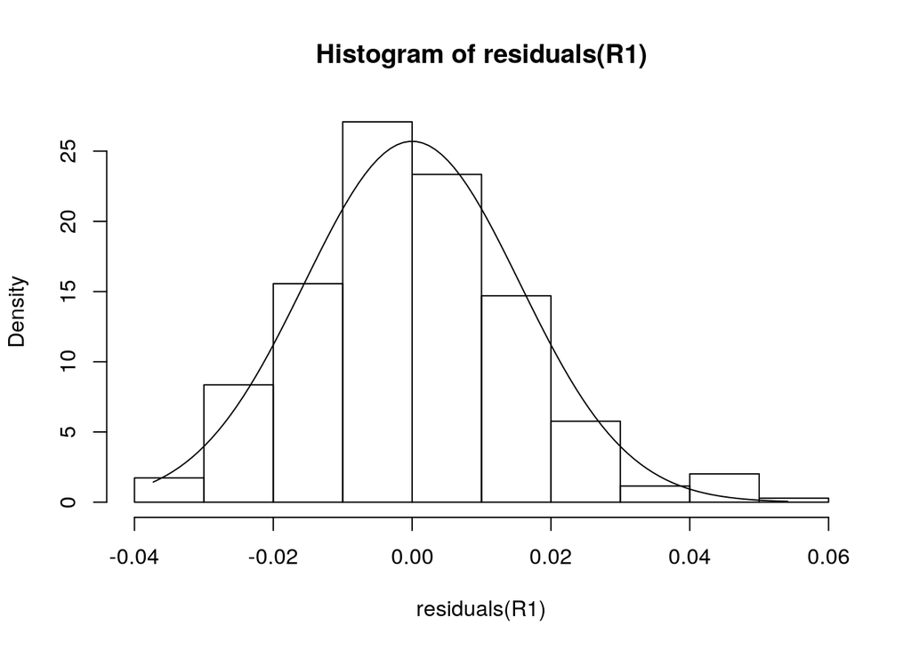

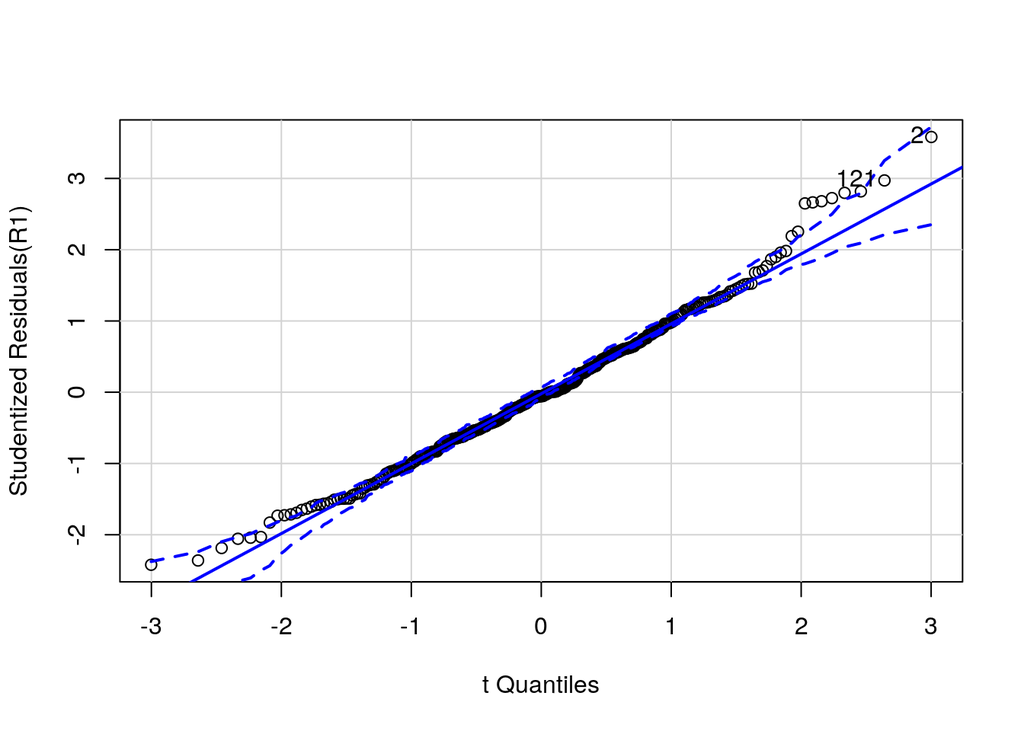

```
## [1]   2 121
```

# 3 Association of genotypes and BMI

First, we tested for an interaction of FTO and Taq1A on BMI.

```
##
## Call:
## lm(formula = BMI_BMI ~ Age_all + factor(sex) + as.factor(FTO_risk) *
##     as.factor(Taq1A_risk), data = final_sample)
##
## Residuals:
##     Min      1Q  Median      3Q     Max
## -9.1313 -1.9410 -0.1105  1.8844 12.3670
##
## Coefficients:
##                                             Estimate Std. Error t value
## (Intercept)                                 17.62491    0.95960  18.367
## Age_all                                      0.14233    0.02000   7.115
## factor(sex)male                              1.56968    0.35465   4.426
## as.factor(FTO_risk)1                         1.07341    0.45092   2.380
## as.factor(FTO_risk)2                         1.91004    0.62470   3.058
## as.factor(Taq1A_risk)1                      -0.82474    0.58999  -1.398
## as.factor(FTO_risk)1:as.factor(Taq1A_risk)1  0.07024    0.85665   0.082
## as.factor(FTO_risk)2:as.factor(Taq1A_risk)1 -0.01714    1.12172  -0.015
##                                             Pr(>|t|)
## (Intercept)                                  < 2e-16 ***
## Age_all                                      6.7e-12 ***
## factor(sex)male                              1.3e-05 ***
## as.factor(FTO_risk)1                         0.01784 *
## as.factor(FTO_risk)2                         0.00241 **
## as.factor(Taq1A_risk)1                       0.16306
## as.factor(FTO_risk)1:as.factor(Taq1A_risk)1  0.93470
## as.factor(FTO_risk)2:as.factor(Taq1A_risk)1  0.98782
## ---
## Signif. codes:  0 '***' 0.001 '**' 0.01 '*' 0.05 '.' 0.1 ' ' 1
##
## Residual standard error: 3.254 on 339 degrees of freedom
## Multiple R-squared:  0.225,  Adjusted R-squared:  0.209
## F-statistic: 14.06 on 7 and 339 DF,  p-value: 5.012e-16
```

```
## Analysis of Variance Table
##
## Model 1: BMI_BMI ~ Age_all + factor(sex) + as.factor(FTO_risk) * as.factor(Taq1A_risk)
## Model 2: BMI_BMI ~ Age_all + factor(sex) + as.factor(FTO_risk) + as.factor(Taq1A_risk)
##   Res.Df    RSS Df Sum of Sq      F Pr(>F)
## 1    339 3589.2
## 2    341 3589.3 -2 -0.095569 0.0045 0.9955
```

Then we estimated the main effect of both genotypes.

```
##
## Call:
## lm(formula = BMI_BMI ~ Age_all + factor(sex) + as.factor(FTO_risk) +
##     as.factor(Taq1A_risk), data = final_sample)
##
## Residuals:
##     Min      1Q  Median      3Q     Max
## -9.1186 -1.9393 -0.1145  1.8967 12.3546
##
## Coefficients:
##                        Estimate Std. Error t value Pr(>|t|)
## (Intercept)            17.62179    0.94678  18.612  < 2e-16 ***
## Age_all                 0.14226    0.01992   7.141 5.62e-12 ***
## factor(sex)male         1.56739    0.35280   4.443 1.20e-05 ***
## as.factor(FTO_risk)1    1.09260    0.38302   2.853 0.004601 **
## as.factor(FTO_risk)2    1.90446    0.51959   3.665 0.000286 ***
## as.factor(Taq1A_risk)1 -0.79971    0.38946  -2.053 0.040800 *
## ---
## Signif. codes:  0 '***' 0.001 '**' 0.01 '*' 0.05 '.' 0.1 ' ' 1
##
## Residual standard error: 3.244 on 341 degrees of freedom
## Multiple R-squared:  0.225,  Adjusted R-squared:  0.2136
## F-statistic:  19.8 on 5 and 341 DF,  p-value: < 2.2e-16
```

Like in the original data, more FTO alleles predicted higher BMI. In the synthetic data, the association of carrying a Taq1A risk allele and lower BMI becomes significant. The same trend was visible in the real data.

# 4 Association of genotypes and reward network connectivity

## 4.1 genotype ~ FA CC

```
## Analysis of Variance Table
##
## Model 1: rel_FA_CC ~ Age_all + factor(sex) + as.factor(Taq1A_risk) + as.factor(FTO_risk)
## Model 2: rel_FA_CC ~ Age_all + factor(sex) + as.factor(Taq1A_risk) * as.factor(FTO_risk)
##   Res.Df    RSS Df Sum of Sq      F Pr(>F)
## 1    341 13.106
## 2    339 12.989  2    0.1167 1.5228 0.2196
```

```
##
## Call:
## lm(formula = rel_FA_CC ~ Age_all + factor(sex) + as.factor(Taq1A_risk) *
##     as.factor(FTO_risk), data = final_sample)
##
## Residuals:
##      Min       1Q   Median       3Q      Max
## -0.53730 -0.12901 -0.01265  0.13072  0.59125
##
## Coefficients:
##                                              Estimate Std. Error t value
## (Intercept)                                  1.790018   0.057728  31.008
## Age_all                                     -0.007315   0.001203  -6.078
## factor(sex)male                             -0.074817   0.021335  -3.507
## as.factor(Taq1A_risk)1                       0.109861   0.035493   3.095
## as.factor(FTO_risk)1                         0.043910   0.027127   1.619
## as.factor(FTO_risk)2                         0.027656   0.037581   0.736
## as.factor(Taq1A_risk)1:as.factor(FTO_risk)1 -0.088887   0.051535  -1.725
## as.factor(Taq1A_risk)1:as.factor(FTO_risk)2 -0.058612   0.067481  -0.869
##                                             Pr(>|t|)
## (Intercept)                                  < 2e-16 ***
## Age_all                                     3.27e-09 ***
## factor(sex)male                             0.000515 ***
## as.factor(Taq1A_risk)1                      0.002130 **
## as.factor(FTO_risk)1                        0.106445
## as.factor(FTO_risk)2                        0.462298
## as.factor(Taq1A_risk)1:as.factor(FTO_risk)1 0.085476 .
## as.factor(Taq1A_risk)1:as.factor(FTO_risk)2 0.385696
## ---
## Signif. codes:  0 '***' 0.001 '**' 0.01 '*' 0.05 '.' 0.1 ' ' 1
##
## Residual standard error: 0.1957 on 339 degrees of freedom
## Multiple R-squared:  0.1466, Adjusted R-squared:  0.129
## F-statistic: 8.319 on 7 and 339 DF,  p-value: 2.217e-09
```

```
##
## Call:
## lm(formula = rel_FA_CC ~ Age_all + factor(sex) + as.factor(Taq1A_risk) +
##     as.factor(FTO_risk), data = final_sample)
##
## Residuals:
##      Min       1Q   Median       3Q      Max
## -0.54961 -0.13790 -0.02131  0.13435  0.55773
##
## Coefficients:
##                         Estimate Std. Error t value Pr(>|t|)
## (Intercept)             1.801598   0.057212  31.490  < 2e-16 ***
## Age_all                -0.007299   0.001204  -6.063 3.54e-09 ***
## factor(sex)male        -0.072918   0.021319  -3.420 0.000701 ***
## as.factor(Taq1A_risk)1  0.064882   0.023534   2.757 0.006149 **
## as.factor(FTO_risk)1    0.019351   0.023145   0.836 0.403700
## as.factor(FTO_risk)2    0.009956   0.031398   0.317 0.751365
## ---
## Signif. codes:  0 '***' 0.001 '**' 0.01 '*' 0.05 '.' 0.1 ' ' 1
##
## Residual standard error: 0.196 on 341 degrees of freedom
## Multiple R-squared:  0.1389, Adjusted R-squared:  0.1263
## F-statistic:    11 on 5 and 341 DF,  p-value: 7.768e-10
```

## 4.2 genotype ~ FA CS

```
## Analysis of Variance Table
##
## Model 1: rel_FA_strength ~ Age_all + factor(sex) + as.factor(Taq1A_risk) +
##     as.factor(FTO_risk)
## Model 2: rel_FA_strength ~ Age_all + factor(sex) + as.factor(Taq1A_risk) *
##     as.factor(FTO_risk)
##   Res.Df      RSS Df  Sum of Sq      F Pr(>F)
## 1    341 0.016532
## 2    339 0.016477  2 5.5289e-05 0.5688 0.5668
```

```
##
## Call:
## lm(formula = rel_FA_strength ~ Age_all + factor(sex) + as.factor(Taq1A_risk) *
##     as.factor(FTO_risk), data = final_sample)
##
## Residuals:
##        Min         1Q     Median         3Q        Max
## -0.0160880 -0.0046755  0.0003869  0.0040970  0.0276833
##
## Coefficients:
##                                               Estimate Std. Error t value
## (Intercept)                                  5.604e-02  2.056e-03  27.256
## Age_all                                     -2.689e-04  4.286e-05  -6.273
## factor(sex)male                             -3.743e-03  7.599e-04  -4.926
## as.factor(Taq1A_risk)1                       3.602e-03  1.264e-03   2.849
## as.factor(FTO_risk)1                         1.789e-03  9.662e-04   1.851
## as.factor(FTO_risk)2                         8.784e-04  1.338e-03   0.656
## as.factor(Taq1A_risk)1:as.factor(FTO_risk)1 -1.947e-03  1.835e-03  -1.061
## as.factor(Taq1A_risk)1:as.factor(FTO_risk)2 -1.169e-03  2.403e-03  -0.486
##                                             Pr(>|t|)
## (Intercept)                                  < 2e-16 ***
## Age_all                                     1.08e-09 ***
## factor(sex)male                             1.31e-06 ***
## as.factor(Taq1A_risk)1                       0.00465 **
## as.factor(FTO_risk)1                         0.06501 .
## as.factor(FTO_risk)2                         0.51211
## as.factor(Taq1A_risk)1:as.factor(FTO_risk)1  0.28961
## as.factor(Taq1A_risk)1:as.factor(FTO_risk)2  0.62709
## ---
## Signif. codes:  0 '***' 0.001 '**' 0.01 '*' 0.05 '.' 0.1 ' ' 1
##
## Residual standard error: 0.006972 on 339 degrees of freedom
## Multiple R-squared:  0.1784, Adjusted R-squared:  0.1614
## F-statistic: 10.52 on 7 and 339 DF,  p-value: 5.7e-12
```

```
##
## Call:
## lm(formula = rel_FA_strength ~ Age_all + factor(sex) + as.factor(Taq1A_risk) +
##     as.factor(FTO_risk), data = final_sample)
##
## Residuals:
##        Min         1Q     Median         3Q        Max
## -0.0163407 -0.0043225  0.0003026  0.0041624  0.0274149
##
## Coefficients:
##                          Estimate Std. Error t value Pr(>|t|)
## (Intercept)             5.628e-02  2.032e-03  27.698  < 2e-16 ***
## Age_all                -2.684e-04  4.275e-05  -6.279 1.04e-09 ***
## factor(sex)male        -3.700e-03  7.572e-04  -4.887 1.58e-06 ***
## as.factor(Taq1A_risk)1  2.636e-03  8.358e-04   3.154  0.00176 **
## as.factor(FTO_risk)1    1.251e-03  8.220e-04   1.522  0.12895
## as.factor(FTO_risk)2    5.262e-04  1.115e-03   0.472  0.63733
## ---
## Signif. codes:  0 '***' 0.001 '**' 0.01 '*' 0.05 '.' 0.1 ' ' 1
##
## Residual standard error: 0.006963 on 341 degrees of freedom
## Multiple R-squared:  0.1756, Adjusted R-squared:  0.1636
## F-statistic: 14.53 on 5 and 341 DF,  p-value: 6.478e-13
```

## 4.3 genotype ~ NOS CC

```
## Analysis of Variance Table
##
## Model 1: rel_NOS_CC ~ Age_all + factor(sex) + as.factor(Taq1A_risk) +
##     as.factor(FTO_risk)
## Model 2: rel_NOS_CC ~ Age_all + factor(sex) + as.factor(Taq1A_risk) *
##     as.factor(FTO_risk)
##   Res.Df    RSS Df Sum of Sq      F Pr(>F)
## 1    341 4311.5
## 2    339 4308.4  2    3.1107 0.1224 0.8849
```

```
##
## Call:
## lm(formula = rel_NOS_CC ~ Age_all + factor(sex) + as.factor(Taq1A_risk) *
##     as.factor(FTO_risk), data = final_sample)
##
## Residuals:
##    Min     1Q Median     3Q    Max
## -5.596 -2.335 -0.623  1.350 18.047
##
## Coefficients:
##                                             Estimate Std. Error t value
## (Intercept)                                  7.66533    1.05136   7.291
## Age_all                                      0.01848    0.02192   0.843
## factor(sex)male                             -0.39235    0.38856  -1.010
## as.factor(Taq1A_risk)1                       0.18083    0.64641   0.280
## as.factor(FTO_risk)1                        -0.37585    0.49404  -0.761
## as.factor(FTO_risk)2                        -0.38705    0.68444  -0.565
## as.factor(Taq1A_risk)1:as.factor(FTO_risk)1  0.02900    0.93856   0.031
## as.factor(Taq1A_risk)1:as.factor(FTO_risk)2 -0.55255    1.22898  -0.450
##                                             Pr(>|t|)
## (Intercept)                                 2.19e-12 ***
## Age_all                                        0.400
## factor(sex)male                                0.313
## as.factor(Taq1A_risk)1                         0.780
## as.factor(FTO_risk)1                           0.447
## as.factor(FTO_risk)2                           0.572
## as.factor(Taq1A_risk)1:as.factor(FTO_risk)1    0.975
## as.factor(Taq1A_risk)1:as.factor(FTO_risk)2    0.653
## ---
## Signif. codes:  0 '***' 0.001 '**' 0.01 '*' 0.05 '.' 0.1 ' ' 1
##
## Residual standard error: 3.565 on 339 degrees of freedom
## Multiple R-squared:  0.01062,    Adjusted R-squared:  -0.009809
## F-statistic: 0.5199 on 7 and 339 DF,  p-value: 0.8195
```

```
##
## Call:
## lm(formula = rel_NOS_CC ~ Age_all + factor(sex) + as.factor(Taq1A_risk) +
##     as.factor(FTO_risk), data = final_sample)
##
## Residuals:
##     Min      1Q  Median      3Q     Max
## -5.5340 -2.3384 -0.5705  1.4145 18.0302
##
## Coefficients:
##                        Estimate Std. Error t value Pr(>|t|)
## (Intercept)             7.71588    1.03768   7.436 8.49e-13 ***
## Age_all                 0.01795    0.02183   0.822    0.412
## factor(sex)male        -0.40003    0.38667  -1.035    0.302
## as.factor(Taq1A_risk)1  0.10077    0.42685   0.236    0.814
## as.factor(FTO_risk)1   -0.36984    0.41979  -0.881    0.379
## as.factor(FTO_risk)2   -0.55748    0.56948  -0.979    0.328
## ---
## Signif. codes:  0 '***' 0.001 '**' 0.01 '*' 0.05 '.' 0.1 ' ' 1
##
## Residual standard error: 3.556 on 341 degrees of freedom
## Multiple R-squared:  0.009906,   Adjusted R-squared:  -0.004611
## F-statistic: 0.6824 on 5 and 341 DF,  p-value: 0.6371
```

## 4.4 genotype ~ NOS CS

```
## Analysis of Variance Table
##
## Model 1: rel_NOS_strength ~ Age_all + factor(sex) + as.factor(Taq1A_risk) +
##     as.factor(FTO_risk)
## Model 2: rel_NOS_strength ~ Age_all + factor(sex) + as.factor(Taq1A_risk) *
##     as.factor(FTO_risk)
##   Res.Df      RSS Df  Sum of Sq      F Pr(>F)
## 1    341 0.085626
## 2    339 0.085281  2 0.00034486 0.6854 0.5046
```

```
##
## Call:
## lm(formula = rel_NOS_strength ~ Age_all + factor(sex) + as.factor(Taq1A_risk) *
##     as.factor(FTO_risk), data = final_sample)
##
## Residuals:
##       Min        1Q    Median        3Q       Max
## -0.033251 -0.010682 -0.000510  0.008684  0.060937
##
## Coefficients:
##                                               Estimate Std. Error t value
## (Intercept)                                  7.399e-02  4.678e-03  15.818
## Age_all                                     -3.365e-04  9.751e-05  -3.450
## factor(sex)male                             -9.135e-03  1.729e-03  -5.284
## as.factor(Taq1A_risk)1                       5.566e-03  2.876e-03   1.935
## as.factor(FTO_risk)1                         3.406e-03  2.198e-03   1.550
## as.factor(FTO_risk)2                         1.842e-03  3.045e-03   0.605
## as.factor(Taq1A_risk)1:as.factor(FTO_risk)1 -4.865e-03  4.176e-03  -1.165
## as.factor(Taq1A_risk)1:as.factor(FTO_risk)2 -2.889e-03  5.468e-03  -0.528
##                                             Pr(>|t|)
## (Intercept)                                  < 2e-16 ***
## Age_all                                      0.00063 ***
## factor(sex)male                             2.26e-07 ***
## as.factor(Taq1A_risk)1                       0.05378 .
## as.factor(FTO_risk)1                         0.12214
## as.factor(FTO_risk)2                         0.54570
## as.factor(Taq1A_risk)1:as.factor(FTO_risk)1  0.24486
## as.factor(Taq1A_risk)1:as.factor(FTO_risk)2  0.59759
## ---
## Signif. codes:  0 '***' 0.001 '**' 0.01 '*' 0.05 '.' 0.1 ' ' 1
##
## Residual standard error: 0.01586 on 339 degrees of freedom
## Multiple R-squared:  0.1142, Adjusted R-squared:  0.09587
## F-statistic: 6.241 on 7 and 339 DF,  p-value: 6.801e-07
```

```
##
## Call:
## lm(formula = rel_NOS_strength ~ Age_all + factor(sex) + as.factor(Taq1A_risk) +
##     as.factor(FTO_risk), data = final_sample)
##
## Residuals:
##       Min        1Q    Median        3Q       Max
## -0.033911 -0.010304 -0.000127  0.008489  0.061499
##
## Coefficients:
##                          Estimate Std. Error t value Pr(>|t|)
## (Intercept)             0.0745944  0.0046244  16.131  < 2e-16 ***
## Age_all                -0.0003353  0.0000973  -3.446  0.00064 ***
## factor(sex)male        -0.0090275  0.0017232  -5.239 2.83e-07 ***
## as.factor(Taq1A_risk)1  0.0031572  0.0019023   1.660  0.09789 .
## as.factor(FTO_risk)1    0.0020634  0.0018708   1.103  0.27083
## as.factor(FTO_risk)2    0.0009713  0.0025378   0.383  0.70216
## ---
## Signif. codes:  0 '***' 0.001 '**' 0.01 '*' 0.05 '.' 0.1 ' ' 1
##
## Residual standard error: 0.01585 on 341 degrees of freedom
## Multiple R-squared:  0.1106, Adjusted R-squared:  0.09754
## F-statistic: 8.479 on 5 and 341 DF,  p-value: 1.403e-07
```

## 4.5 Exploratory analysis in normal-weight participants

```
##
## FALSE  TRUE
##   193   154
```

```
## Analysis of Variance Table
##
## Model 1: rel_NOS_strength ~ Age_all + factor(sex) + as.factor(FTO_risk)
## Model 2: rel_NOS_strength ~ Age_all + factor(sex)
##   Res.Df      RSS Df  Sum of Sq      F Pr(>F)
## 1    149 0.041794
## 2    151 0.043046 -2 -0.0012522 2.2322 0.1109
```

```
##
## Call:
## lm(formula = rel_NOS_strength ~ Age_all + factor(sex) + as.factor(FTO_risk),
##     data = final_sample_nw)
##
## Residuals:
##       Min        1Q    Median        3Q       Max
## -0.036130 -0.009677 -0.001088  0.010544  0.055416
##
## Coefficients:
##                        Estimate Std. Error t value Pr(>|t|)
## (Intercept)           0.0801599  0.0064859  12.359  < 2e-16 ***
## Age_all              -0.0004370  0.0001399  -3.124  0.00214 **
## factor(sex)male      -0.0029995  0.0028975  -1.035  0.30225
## as.factor(FTO_risk)1  0.0025557  0.0029642   0.862  0.38997
## as.factor(FTO_risk)2  0.0095142  0.0045684   2.083  0.03899 *
## ---
## Signif. codes:  0 '***' 0.001 '**' 0.01 '*' 0.05 '.' 0.1 ' ' 1
##
## Residual standard error: 0.01675 on 149 degrees of freedom
## Multiple R-squared:  0.08977,    Adjusted R-squared:  0.06533
## F-statistic: 3.674 on 4 and 149 DF,  p-value: 0.00696
```